# Exploring Inefficiencies and Bail Reform in Cook County Criminal Justice System

Damini Sharma

[SAO data](https://datacatalog.cookcountyil.gov/browse?tags=state%27s%20attorney%20case-level&sortBy=most_accessed)

[Chicago Data Collaborative](https://chicagodatacollaborative.org/)

[GitHub Repository](https://github.com/DSharm/CookCountyCriminalJustice)

### Background

The Cook County State’s Attorney’s Office (SAO) is the second largest prosecutor’s office in the United States. Tens of thousands of criminal cases are prosecuted every year by the Office, across 100 law enforcement jurisdictions and in service of over five million residents of Cook County. When she took office in December 2016, State’s Attorney Kim Foxx announced a largely unprecedented commitment to improving the transparency of the SAO’s work. Accordingly, in 2017 the SAO released a Baseline Data Report, along with de-identified data capturing snapshots of all cases that go through the SAO from arrest to sentencing. While some of the data goes as far back as the early 2000s, due to changes in the accuracy of storing and reporting the data, it is more reliable starting in 2011.

#### Criticism of SAO

Cook County has been criticized of having excessive lags in the process from arrest to sentencing. Such long delays can prove incredibly disruptive in the life of a defendant, especially if they are held in jail. Using the data released by the SAO, I would like to see if the data does, indeed, show long lags between incident, arrest, felony review, arraignment, and sentencing. In particular, I’d be interested to see whether these lags have any variation when looked at across time, types of offenses, districts, or judges. Understanding these nuances could shed light on where the bottleneck is happening, if at all.

In addition to excessive lags, recent media attention has shed light on the arbitrary decision-making in bond court and how it penalizes the poor. Many people are held pretrial simply because they cannot pay the bail amount, rather than being held because they pose a flight risk. The data on this topic is unfortunately sparse, and the SAO data also does not capture any information on this step of the process.

However, the subject received greater attention in Chicago when SA Kim Foxx announced in June 2017 that her office was pushing to reform this arbitrary system and recommending courts post no bail amount for defendants who don’t present a flight risk. Following that, the Governor signed into law a bill pushed by SA Foxx to this effect. External organizations, such as Chicago Appleseed, have written about this subject and compiled their own datasets, using bond court observations and data requested from the Bond Court through FOIA requests. Some of this data has been made public. While it is not as robust or rich as the SAO data, I explore the data requested from Bond Court to see if there are signs of change or improvement since the bill was passed.

### Case Length: Arrest To Sentencing

I start by looking at the Sentences data from the SAO to see how the average length of case (from arrest to sentencing) has changed from 2011 to 2018. In addition to the average case length, I plot total number of defendants per month that are sentenced and the total number of days spent on cases each month in the same time period. All three are plotted as percentage of the February 2011 value. Note, throughout the analysis I restrict the datasets to only include the top-level charge of a case-participant (since case-participants can have numerous charges. We revisit this point later).

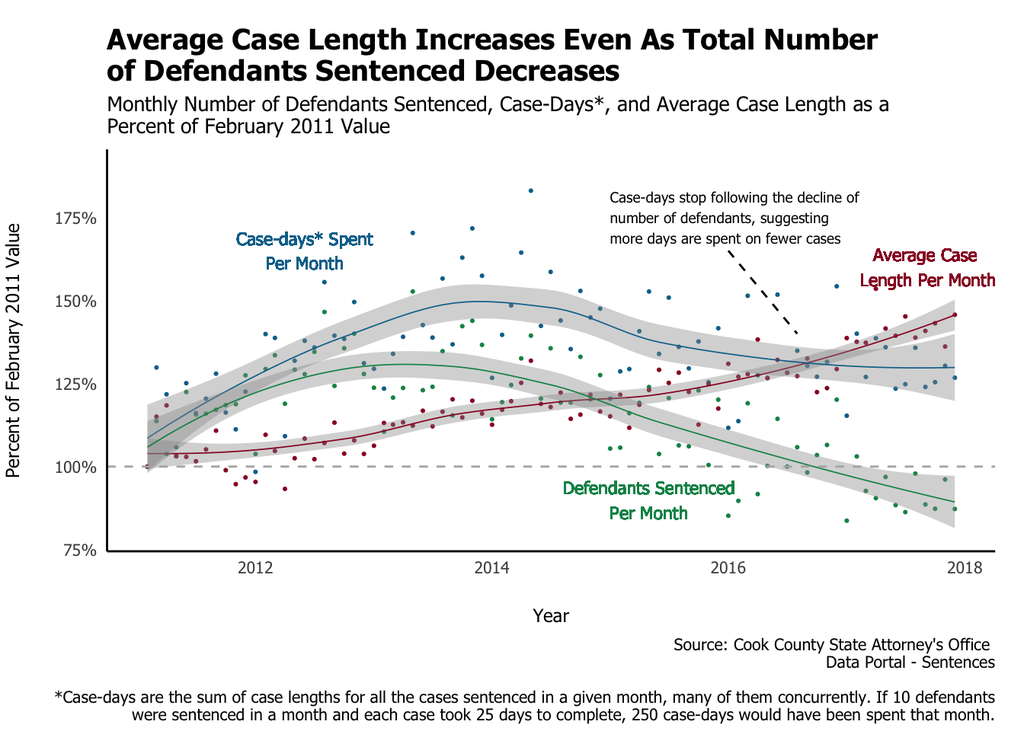

### Breakdown of Offense Types

To explain this trend further, I turn to types of offenses. I want to understand which offense types are driving the decline in number of defendants, as well as which offense types are driving the rise in total number of days spent. In order to do this, I first look at the breakdown of offense types for all cases sentenced from 2011 to 2018.

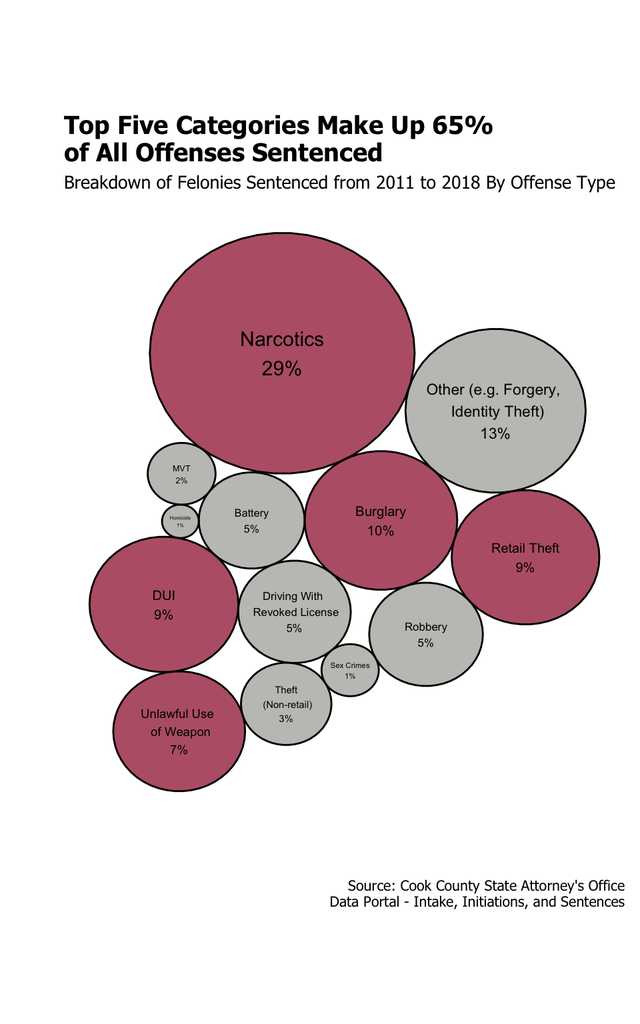

It should be noted here that defendants can have multiple offense types. For example, someone arrested for burglary may also have been found with drugs on them, and may be prosecuted and sentenced for both charges separately. Instead of using offense types at the charge level, I use the broad “Offense Type” variable from the Intake file, which represents all case participants – not charges – that are brought in to the SAO for review. If the SAO decides to prosecute, a case is “initiated” and the specific charges are determined. To simplify the analysis, I use the broad offense type from the Intake file and merge this onto the sentences data, which is already restricted to the top level charge.

### Different Offenses Over Time

Next, I want to look at which of these offenses are, over time, contributing to the trend of decreasing number of cases we saw in the first graph.

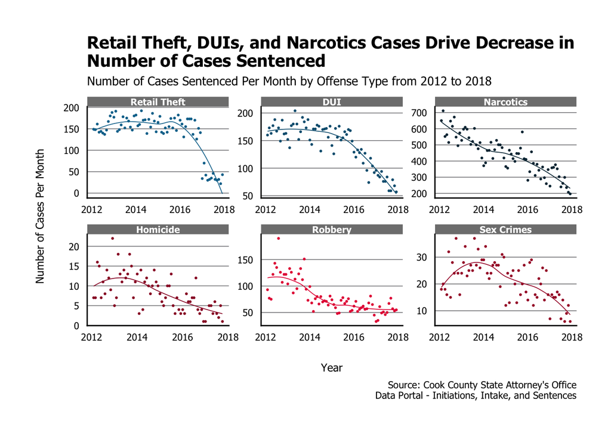

The above graph plots total number of felonies sentenced from 2012 to 2018, faceted by offense type, for the 6 offense types that had the greatest absolute percentage change in number of felonies from 2012 to 2018. Note, the window now starts at 2012 instead of 2011. This is because the Intake data begins in 2011, and since I’ve only kept the universe of case participants that are in both Intake and Sentences datasets, I shortened the window. Otherwise, cases that take longer to prosecute (e.g. homicide) would exist in very small numbers in 2011 if they were only initiated in 2011, which would artificially deflate the number of homicide convictions.

From the above graph, we see that retail theft, DUIs and narcotics are driving the decline in number of cases sentenced. These trends are partially explained by policy changes instituted by former Governor Rauner and State’s Attorney Kim Foxx. Starting in 2011, Chicago had decriminalized possession of small amounts of marijuana, and a statewide bill approved in July 2016 by Governor Rauner further forced police officers to stop arresting those caught with small amounts of drugs. Also in late 2016, SA Kim Foxx announced that retail-theft cases would be considered misdemeanors (not felonies) unless the suspect stole merchandise worth $1,000 or higher. Until this change, the threshold was $300. This policy change can clearly be seen in the steep drop in retail-theft cases around 2017.

### Case Lengths By Offense Type

Having better understood which offense types are driving the decline in number of cases, I turn to looking at which offense types are driving the increase in case length.

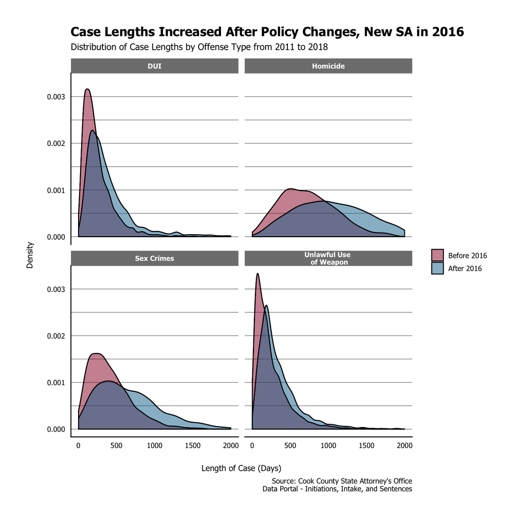

For the figure above, I choose 2016 as the cut off since there were a number of changes in that year that may have impacted the system as a whole, such as the policy changes mentioned above and the election of a new State’s Attorney.

The distribution of case lengths shifts right across all offense types, though it is not clear why. One explanation is that this is a purely mechanical effect - since “lower level” crimes are falling, the crimes left to prosecute are crimes that naturally take longer to prosecute, and this shifts the distribution. However, this explanation does not fully explain why the total number of days spent on cases in the first graph is holding steady or increasing, because there should still be a mechanical decline in time spent if fewer cases are being prosecuted. A second explanation is that there is something about the changes in 2016 causing this increase in case length - new State’s Attorneys often come in with a new set of priorities and procedures, and those could be causing lags.

### Beyond Offense Types

#### Variation in Case Length by Judges and Circuit Court Districts

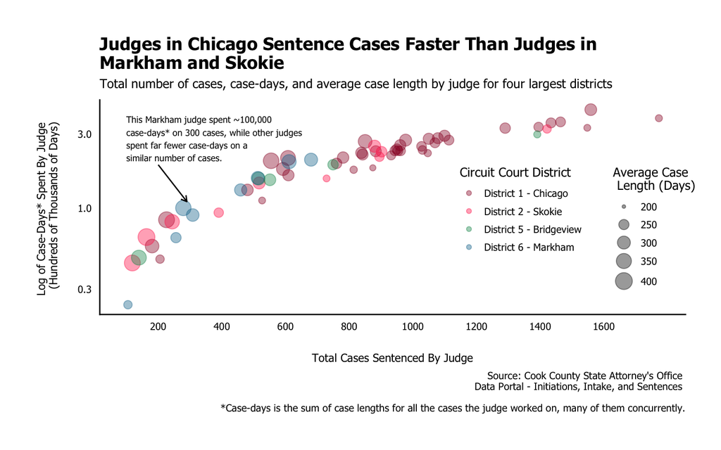

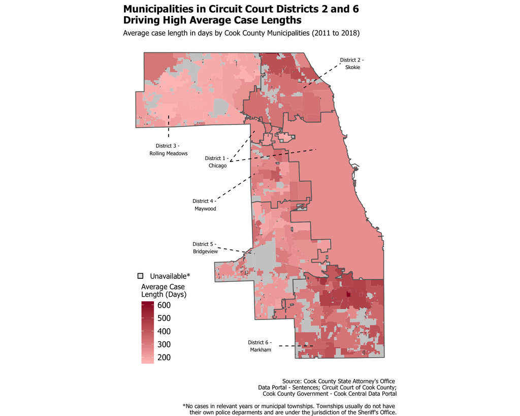

The figure above allows us to see the spatial variation in average case length, across the municipalities in Cook County. The SAO data has information on the Law Enforcement Agency (LEAs) that handled a given case, which maps onto the municipalities in Cook County. Consistent with the graph above we see that cases handled by LEAs in municipalities that are in the southern court district (District 6), as well as those in District 2 have a higher average case length than other districts.

### Variation in Conviction Rates

The SAO data also contains information on the disposition of each charge. That is, whether the charge resulted in a conviction (e.g. finding of guilt, guilty plea, etc) or not (e.g. SAO refused to prosecute, case dismissed, no finding of guilt). The figure above takes only the primary charge for each case-participant and plots the conviction rate by municipalities in Cook County.

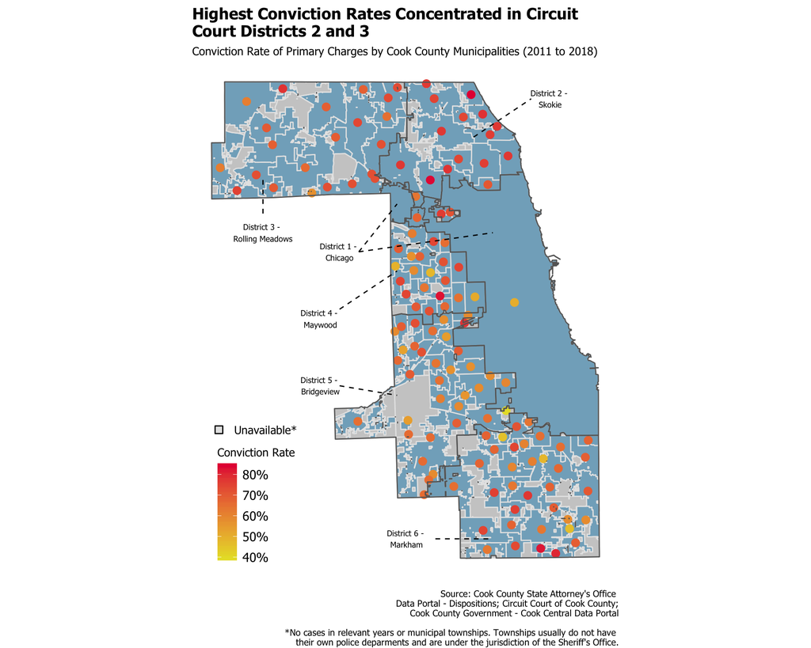

### Impact of Bail Reform Bill

Turning to the Bail Reform bill, I analyze the Bond Court Disposition dataset collected by Chicago Appleseed through FOIA requests to explore the preliminary impact of the bill. Illinois law has a number of options for pretrial release, supervision, and incarceration. These include:

- I-Bonds: Individual recognizance bonds. When an accused person is given an I-Bond, the judge sets a dollar amount which must be paid if the accused fails to appear in court, but no payment is required prior to being released.
- EMI: A person is allowed to be released into house arrest with electronic monitoring (EM)
- D-Bond: Deposit Bond. If an accused receives a D-Bond, they must pay 10% of the D-Bond amount in order to be released from jail.
- C-Bond: Cash Bond. If an accused receives a C-Bond, they must pay the full amount of the Cash Bond to be released.
- No Bail: the accused are ordered incarcerated until the duration of their case
- Bond to stand: Judge upholds a bond type previously set by another judge
- Nolle Pros: Judge decides to not proceed with the case

Using the Bond Court Disposition data, I look at the percentage of cases receiving the various bond types before and after the bill is passed.

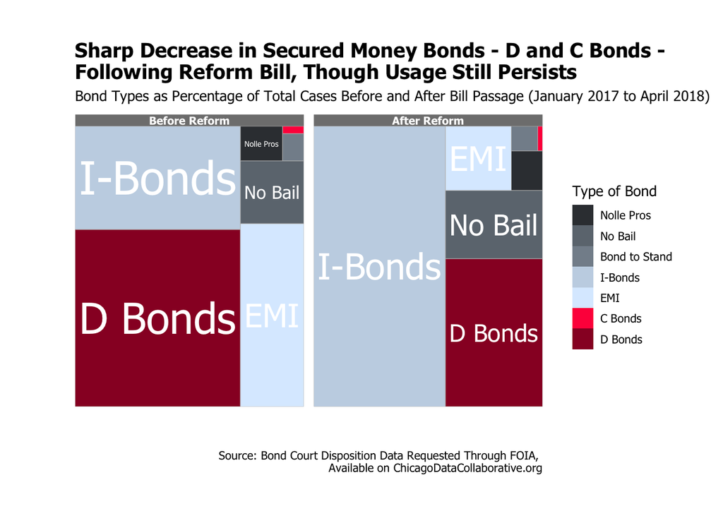

We see that after the reform bill is passed in September 2017, usage of D-Bonds falls sharply while usage of I-Bonds increases. This is certainly an improvement, as fewer people have to pay a cash amount to ensure their release. However, D-Bonds are still given to roughly 20% of cases after the reform. Because of the aggregated nature of the Bond Court Dispositions data received through FOIA, any variation in bond decisions by offense type or judges is masked.